# LAB10_Apredizaje No Supervisado

# Clustering Jerarquico

La función $\texttt{hclust()}$ implementa la agrupación jerárquica en R. En el siguiente ejemplo utilizamos los mimos datos de con que utilizamos k-medias (sección anterior). Para graficar el dendrograma de agrupamiento jerarquico utilizando enlace completo, única (single) y promedio, con la distancia euclidia como medida de disimilitud. Comenzamos por la agrupación de observaciones utilizando un enlace completo. Se utiliza la función $\texttt{dist()}$ para calcular la matriz de distancia euclidia inter-observación 50 × 50.

```r
hc.complete =hclust(dist(x), method ="complete")
```

también se puede realizr un clusterin jerarquico con enlace single y promedio en vez

```r
hc.average =hclust(dist(x), method ="average")
```

```r
hc.single =hclust(dist(x), method ="single")
```

Ahora podemos hacer un plot los dendrogramas obtenidos usando la función usual $\texttt{plot()}$. Los números en la parte inferior de la gráfica identifican cada observación.

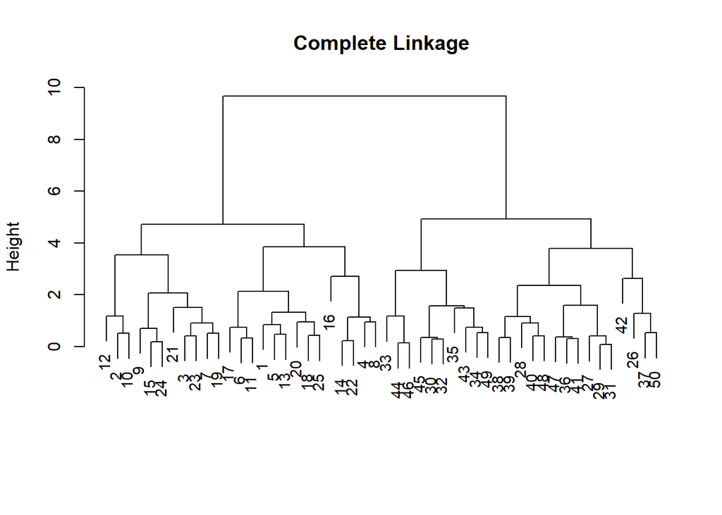

```r
plot(hc.complete ,main =" Complete Linkage ", xlab="", sub ="",
cex =.9)
```

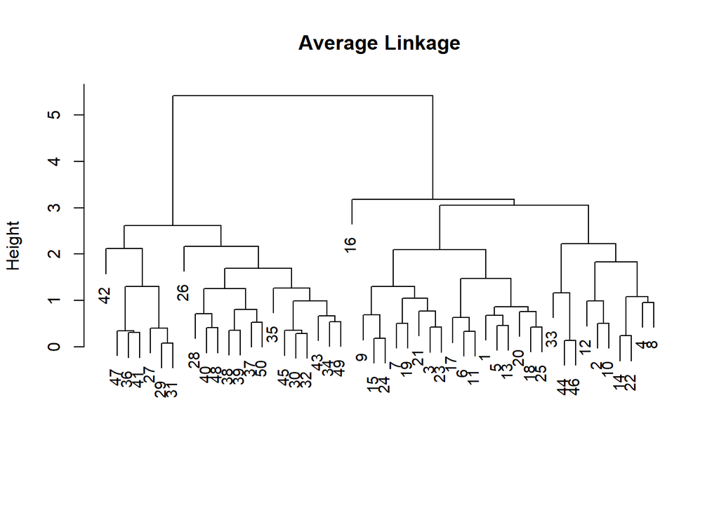

```r
plot(hc.average , main =" Average Linkage ", xlab="", sub ="",
cex =.9)
```

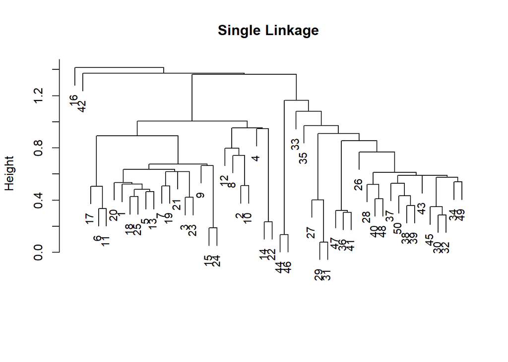

```r
plot(hc.single , main=" Single Linkage ", xlab="", sub ="",
cex =.9)
```

Para determinar las etiquetas de clúster para cada observación asociada con un corte del dendrograma, se puede usar la función $\texttt{cutree()}$:

```r
cutree (hc.complete, 2)
```

```
##  [1] 1 1 1 1 1 1 1 1 1 1 1 1 1 1 1 1 1 1 1 1 1 1 1 1 1 2 2 2 2 2 2 2 2 2 2 2 2 2
## [39] 2 2 2 2 2 2 2 2 2 2 2 2
```